# Les comportements électoraux varient-ils selon le type d’élection (locale, nationale, européenne) en Indre-et-Loire ?

Bastien Barthélémy Illan Callegari Théo Joseph

# 1 **- Introduction**

Le vote est une valeur chère à la démocratie, car celui-ci permet de défendre ses valeurs, de par le choix d’un gouvernement au pouvoir, élu par le peuple. Historiquement, voici l’évolution du droit de vote en France :

- 1791 : **Suffrage censitaire indirect**, les hommes de plus de 25 ans payant un impôt (le cens) ont le droit de voter.
- 1799 : **Premier suffrage universel masculin**, tous les hommes de plus de 21 ans ayant demeuré plus d’un an sur le territoire peuvent voter.
- 1848 : **Le vote devient secret.**
- 1944 : **Le droit de vote des femmes et suffrage universel**, suite à leurs efforts durant la Seconde Guerre Mondiale, les femmes votèrent pour la première fois en avril 1945 pour les élections municipales.
- 1974 : **Droit de vote passe de 18 à 21 ans**

On remarque en effet que le droit de vote n’a pas toujours été celui que l’on connait aujourd’hui. Il y avait d’abord une ségrégation salariale et sexuelle, puis seulement sexuelle en 1799, et le droit de vote sera accordé aux femmes **presque 150 ans après celui accordé aux hommes sans contrainte sociale !**

Cette démonstration historique montre qu’en théorie, le peuple vote selon leurs besoins. Cependant, il se peut que des inscrits sur les listes électorales se déplacent pour aller voter blanc, ou même que des inscrits n’aillent pas du tout voter. On peut alors se demander si *ces comportements varient en fonction des élections*. Est-ce que la population voit les élections régionales d’une aussi grande importance que les élections nationales ?

Nous allons donc étudier ce sujet à partir de graphiques que nous avons concoctés.

# 2 **- Présentation de la base de données**

Notre base de données est celle étudiée en cours et traite du sujet des élections en **Indre-et-Loire**.

## 2.1 Quelles élections ?

Durant notre dossier, nous étudierons les élections suivantes :

- Le premier tour des élections **municipales**
- Le premier tour des élections **régionales**
- Le premier et le second tour des élections **présidentielles**
- Le premier tour des élections **européennes**

## 2.2 Quelles communes ?

Pour simplifier l’analyse de la question, nous allons réduire la base de données aux 10 plus grandes communes de la région Indre-et-Loire **en termes d’inscrits** :

- Tours
- Saint-Cyr-Sur-Loire
- Saint-Avertin
- Saint-Pierre-Des-Corps
- Fondettes
- Amboise
- Chambray-Lès-Tours
- Ballan-Miré
- La Riche
- Chinon

## 2.3 Quelles modalités ?

Nous avons décidé de réduire la base de données en supprimant les variables inutiles pour la rendre la plus lisible possible. Ce qui nous donne une base de données qui traite des variables suivantes :

- Nombre d’**inscrits**
- Nombre d’**abstentions**
- Nombre de **votes**
- Nombre de **votes blancs**
- Nombre de **votes nuls**
- Nombre de **votes exprimés**

| Commune | Inscrits | Abstentions | Votants | Blancs | Nuls | Exprimés |
| --- | --- | --- | --- | --- | --- | --- |
| Tours | 83933 | 41451 | 42482 | 376 | 413 | 41693 |
| Saint-Cyr-Sur-Loire | 12771 | 4888 | 7883 | 89 | 66 | 7728 |
| Saint-Avertin | 11957 | 4896 | 7061 | 82 | 76 | 6903 |
| Saint-Pierre-Des-Corps | 10324 | 5562 | 4762 | 53 | 64 | 4645 |
| Fondettes | 9406 | 3942 | 5464 | 62 | 54 | 5348 |
| Amboise | 9251 | 4532 | 4719 | 52 | 76 | 4591 |
| Chambray-Lès-Tours | 8129 | 3755 | 4374 | 50 | 50 | 4274 |
| Ballan-Miré | 6688 | 2817 | 3871 | 63 | 27 | 3781 |
| La Riche | 6610 | 3167 | 3443 | 43 | 43 | 3357 |
| Chinon | 6305 | 3062 | 3243 | 52 | 23 | 3168 |

Nous avons calculé des **proportions** pour chacunes des variables afin que ce soit plus parlant :

| Commune | %Abs/Ins | %Vot/Ins | %Blancs/Vot | %Nuls/Vot | %Exp/Ins |
| --- | --- | --- | --- | --- | --- |
| Tours | 49.39 | 50.61 | 0.89 | 0.97 | 49.67 |
| Saint-Cyr-Sur-Loire | 38.27 | 61.73 | 1.13 | 0.84 | 60.51 |
| Saint-Avertin | 40.95 | 59.05 | 1.16 | 1.08 | 57.73 |
| Saint-Pierre-Des-Corps | 53.87 | 46.13 | 1.11 | 1.34 | 44.99 |
| Fondettes | 41.91 | 58.09 | 1.13 | 0.99 | 56.86 |
| Amboise | 48.99 | 51.01 | 1.10 | 1.61 | 49.63 |
| Chambray-Lès-Tours | 46.19 | 53.81 | 1.14 | 1.14 | 52.58 |
| Ballan-Miré | 42.12 | 57.88 | 1.63 | 0.70 | 56.53 |
| La Riche | 47.91 | 52.09 | 1.25 | 1.25 | 50.79 |
| Chinon | 48.56 | 51.44 | 1.60 | 0.71 | 50.25 |

# 3 **- Étude sur le taux d’abstention**

## 3.1 Pour quelles élections il y a t-il le plus fort taux d’abstention ?

L’étude que nous avons faite sur le taux d’abstention se base sur les élections qui se sont déroulées entre 2020 et 2024 car les mandats ont d’une certaine durée pour chaque élection. Ils sont d’une durée de :

- 5 ans pour les **présidentielles** et **les européennes**
- 6 ans pour les **régionales** et les **municipales**

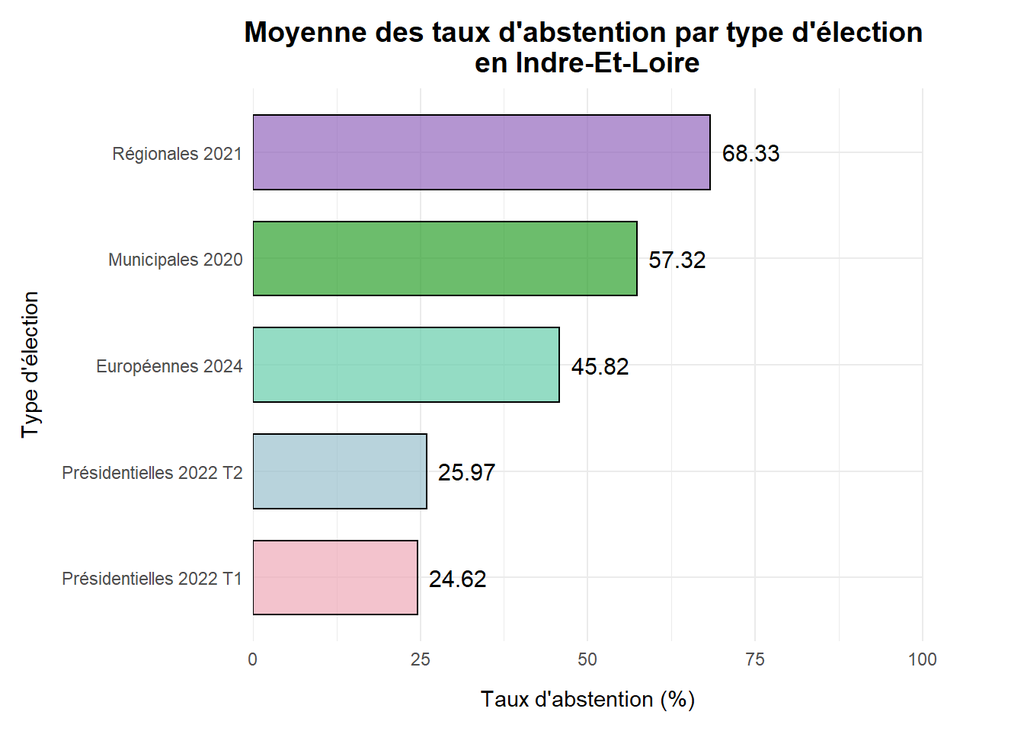

En étudiant la moyenne des taux d’abstention sur les dernières élections pour chaque type, nous pouvons remarquer que le **taux d’abstention le plus faible** se trouve sur le premier (24,62%) et le second (25,97%) tour de la dernière élection présidentielle. Ce taux double presque lors des élections européennes (45,82%) et est encore plus élevé pour les municipales (57,32%). Enfin, **le trophée du plus fort taux d’abstention revient aux élections régionales avec… 68,33%** 🏆.

Cependant, comme le taux d’abstention est très proche entre le premier et le second tour des élections présidentielles, on peut se demander, toujours en analysant les métropoles, **comment le taux d’abstention a évolué entre les dernières et les avant-dernières élections ?**

## 3.2 Comment a évolué le taux d’abstention ces dernières années ?

Pour cette étude, nous allons **comparer le taux d’abstention des élections les plus récentes avec celles d’avant**. Pour cela, nous allons utiliser les données des élections :

- Municipales de **2014**
- Régionales de **2015**
- Présidentielles de **2017**
- Européennes de **2019**

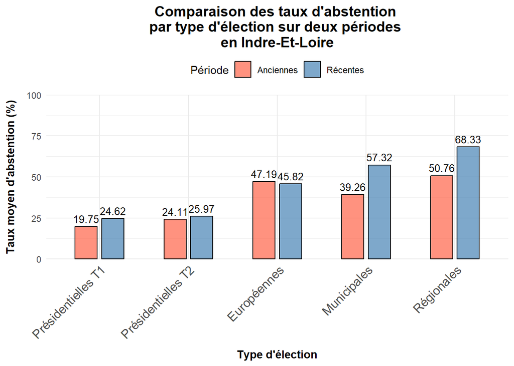

**Présidentielles T1 :** Une **augmentation du taux d’abstention de 4,87 points de pourcentage** est constatée entre 2017 et 2022. Cela reflète une **diminution de l’implication électorale** dès le premier tour des élections présidentielles récentes.

**Présidentielles T2 :** Le taux d’abstention a également **augmenté de 1,86 point de pourcentage** entre 2017 et 2022, bien que cette augmentation soit moins marquée que celle observée au premier tour.

**Européennes :** Une légère **diminution de 1,37 point de pourcentage** est notée entre les deux périodes comparées (2019 et 2024), indiquant un **regain d’intérêt** pour ce scrutin européen.

**Municipales :** Une **forte augmentation de 18,06 points de pourcentage** est enregistrée entre 2014 et 2020. Ce constat met en évidence un **net désintérêt** des citoyens pour les élections locales lors des dernières élections.

**Régionales :** Une **hausse significative de 17,57 points de pourcentage** est observée entre 2015 et 2021, confirmant une tendance similaire à celle des municipales, avec un **fort recul** de la participation.

Les résultats montrent une **tendance croissante à l’abstention dans presque toutes les catégories d’élections en France**, avec des augmentations significatives enregistrées notamment lors des **élections municipales et régionales**.

Cependant, l’abstention n’est **pas la seule manière pour les citoyens de manifester leur désaccord** à l’égard des choix politiques. Le vote blanc offre une alternative pour exprimer une position active plutôt que passive. Contrairement à l’abstention, **le vote blanc traduit un engagement dans le processus démocratique tout en marquant une insatisfaction à l’égard des options proposées**.

# 4 **- Étude sur le vote blanc**

## 4.1 Comment évolue les votes blancs entre le premier et le second tour des présidentielles ?

Dans cette partie, nous étudierons l’**évolution du vote blanc entre le premier et le second tour des dernières élections présidentielles**, afin de mettre en lumière les **dynamiques sous-jacente à ce phénomène**.

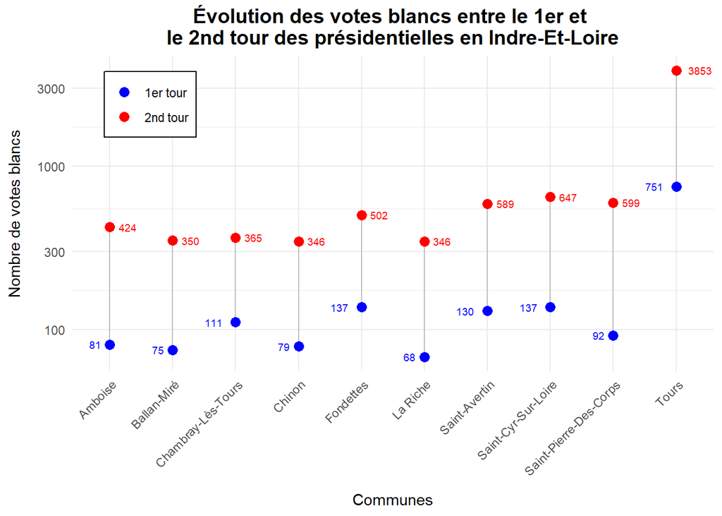

À travers l’étude des 10 plus grandes métropoles, on constate qu’au second tour, le nombre de votes blancs est **toujours plus élevé qu’au premier tour des présidentielles**. On peut émettre l’hypothèse que le choix restreint entre deux personnalités politiques limite les options disponibles, ce qui conduit certains électeurs à ne pas trouver de représentant convaincant. Cela pourrait donc expliquer l’augmentation du taux d’abstention. Mais alors, **pourquoi certaines personnes se déplaceraient-elles pour voter si leur objectif est de voter blanc ?** Cela traduit un mécontentement profond, car une hausse du nombre de votes blancs indique qu’**aucun candidat ne représente leurs intérêts.**

# 5 **- Étude sur le vote à l’étranger**

## 5.1 Les votants d’Indre-et-Loire suivent-ils la même tendance à voter que les européens ?

Nous nous sommes dit qu’il aurait été intéressant de voir si ce **fort taux d’abstention** était un **phénomène français** ou s’il est également présent dans les autres pays.

Afin d’évaluer si les taux d’abstention observés dans les communes étudiées diffèrent significativement du taux moyen d’abstention des autres pays, nous avons effectué des *tests de comparaison* d’une proportion à un standard pour chaque commune. Nous allons donc nous concentrer sur la base de données contenant des informations sur les élections européennes de 2024.

**Selon les données officielles du Parlement européen**, le taux d’abstention moyen dans l’Union Européenne lors des élections européennes 2024 est de **49,26%**. Ces données sont disponibles sur le [site du Parlement Européen](https://results.elections.europa.eu/en), une source institutionnelle fiable qui centralise les résultats pour les 27 États membres. Nous allons donc utiliser cette valeur comme valeur de base.

### 5.1.1 Méthodologie :

**Hypothèses du test :** **H0 :** la proportion d’abstention dans la commune n’est pas significativement différente de p0. **H1 :** la proportion d’abstention dans la commune est significativement différente de p0.

**Seuil de signification (α) :** Nous avons fixé le **seuil de signification à 5 %**.

**Conditions du test :** Le test de proportion est valide si la **taille de l’échantillon est suffisamment grande**. Toutes les communes étudiées ont un nombre d’inscrits supérieur à 6 000, **ce qui satisfait cette condition**.

### 5.1.2 Résultats :

Pour chaque commune, le test renvoie :

- La **proportion observée**.
- Un **intervalle de confiance (IC) à 95 %** autour de cette proportion.
- Une **p-value** indiquant la significativité de la différence entre la proportion observée et la valeur de référence.
- Une **interprétation qualitative** indiquant si la différence est significative ou non.

Les résultats sont résumés dans le tableau ci-dessous :

|  | Proportion Observée | Borne inf. IC 95% (Inf) | Borne sup. IC 95% (Sup) | p-value | Significatif |
| --- | --- | --- | --- | --- | --- |
| Tours | 0.49 | 0.48 | 0.50 | 0.570882 | Non |
| Saint-Cyr-Sur-Loire | 0.42 | 0.41 | 0.43 | 0.000000 | Oui |
| Saint-Avertin | 0.46 | 0.45 | 0.47 | 0.000000 | Oui |
| Saint-Pierre-Des-Corps | 0.49 | 0.47 | 0.50 | 0.251456 | Non |
| Fondettes | 0.42 | 0.41 | 0.43 | 0.000000 | Oui |
| Amboise | 0.48 | 0.47 | 0.49 | 0.025624 | Oui |
| Chambray-Lès-Tours | 0.41 | 0.40 | 0.42 | 0.000000 | Oui |
| Ballan-Miré | 0.38 | 0.37 | 0.39 | 0.000000 | Oui |
| La Riche | 0.54 | 0.53 | 0.55 | 0.000000 | Oui |
| Chinon | 0.49 | 0.49 | 0.50 | 0.564595 | Non |

Une p-value < 0.05 indique que **la différence entre la proportion observée et p0 est significative**. Une p-value ≥ 0.05 indique que cette **différence n’est pas significative**.

Dans les résultats de notre analyse, **certaines p-values sont affichées comme 0.0000**. Cela ne signifie pas que ces p-values sont strictement égales à zéro, mais qu’**elles sont extrêmement faibles**, inférieures à 10-4, en raison des limites d’affichage. Ces résultats traduisent une très forte évidence statistique contre l’hypothèse H0. Ils s’expliquent par une combinaison de la **taille importante** des échantillons et des **différences significatives** entre les proportions observées dans certaines communes et la moyenne européenne. Ces résultats confirment que, dans ces cas, **les taux d’abstention observés diffèrent significativement de la proportion de référence, validant ainsi l’hypothèse alternative.**

### 5.1.3 Analyse des résultats :

Communes avec des **proportions non significativement différentes** de p0 : Les communes comme Tours, Saint-Pierre-Des-Corps, et Chinon présentent des proportions d’abstention non significativement différentes du taux moyen européen. Pour ces communes, on ne peut pas conclure qu’il existe une différence notable avec le taux européen.

### 5.1.4 Conclusion du test :

Les tests montrent que les taux d’abstention dans certaines communes diffèrent significativement du taux moyen européen, ce qui pourrait être lié à des facteurs locaux spécifiques. **Ces résultats permettent de mettre en lumière des particularités dans les comportements électoraux au niveau communal.** Toutefois, pour les communes où aucune différence significative n’est observée, il est raisonnable de considérer que leur taux d’abstention est conforme à la moyenne européenne.

# 6 **- Conclusion**

Durant cette étude nous avons remarqué que **les gens n’accordent pas la même importance aux différents types d’élections**.